This is to illustrate central limit theorem in rmarkdown using bootstrap. This is to perform using to random sample and 2 expoenetial sample and produce histogram for both original sample and bootstram sample to illustrate central limit theorem and also to upload the rmarkdown file to Github.

I am taking 2 sample normal randon sample of size 10 and 20 and exponential sample of size 10 and 20.

```r
##Two rnorm samples of differing sample sizes
smpl1 <- rnorm(10,0,10)  #first sample of size 10.
smpl2 <- rnorm(20,0,10)  #second sample of size 20.

##Two rexp samples of differing sample sizes
expnsmpl1 <- rexp(10)  #small sample size
expnsmpl2 <- rexp(20) #large sample size

##vector to hold the 1000 samples.

r <-1000
bootmeansmpl1 <- numeric(r)
bootmeansmpl2 <- numeric(r)
bootmeanexpn1 <- numeric(r)
bootmeanexpn2 <- numeric(r)

##this is bootstrap for loop to thsat run 1000 sample for above define vectors.
# and to define means of 1000 samples of our original dataset.

for (i in 1:r) {
  bootsmpl1 <- sample(smpl1, size = length(smpl1), replace =T )
  bootsmpl2 <- sample(smpl2, size = length(smpl2), replace =T )
  bootexpn2 <- sample(expnsmpl2, size = length(expnsmpl2), replace =T )
  bootexpn1 <- sample(expnsmpl1, size = length(expnsmpl1), replace =T )
  bootmeansmpl1[i] <- mean(bootsmpl1)
  bootmeansmpl2[i] <- mean(bootsmpl2)
  bootmeanexpn1[i] <- mean(bootexpn1)
  bootmeanexpn2[i] <- mean(bootexpn2)
}
```

Now here we have produce histogram of original random normal sample of 10 and 20 samples. and boostrap sample for the mean of 1000 samples.

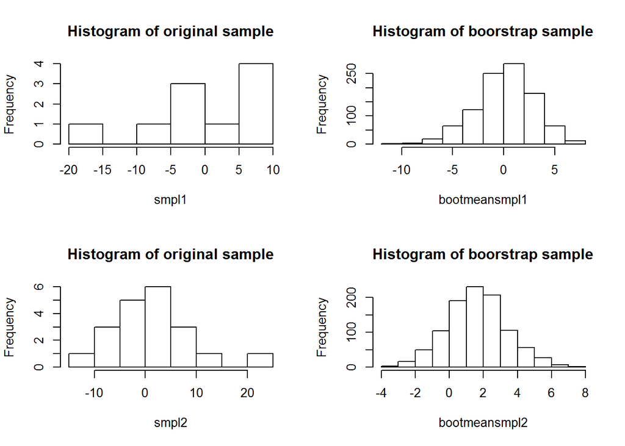

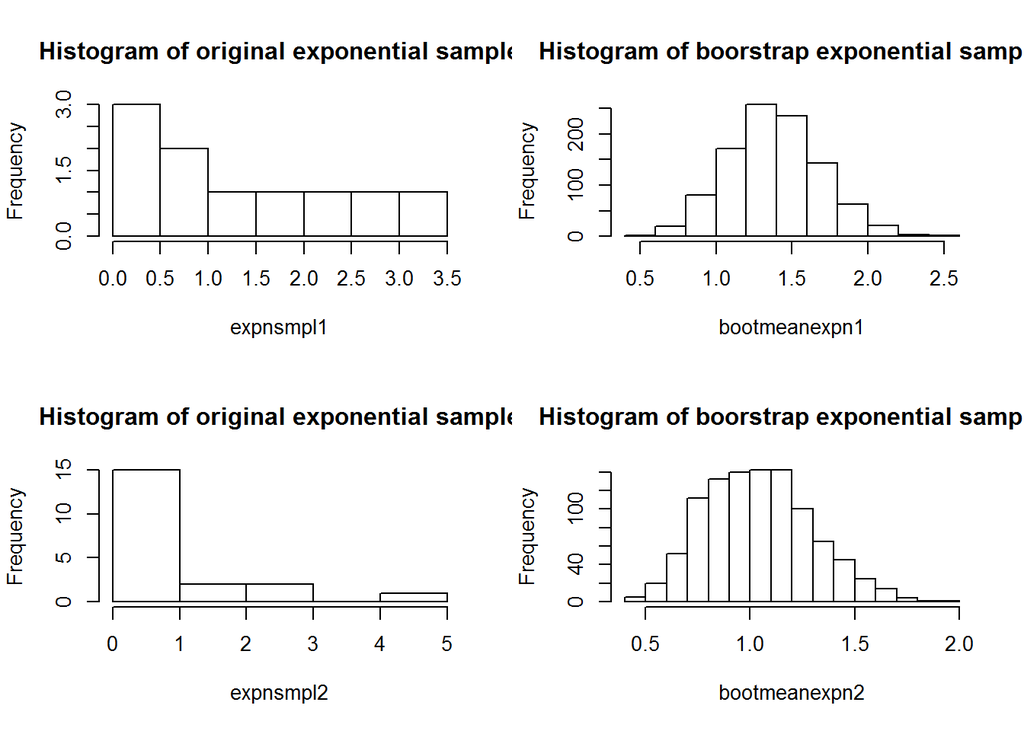

You see clearly that the original dataset is skewed, but when randomly samples through a bootstrap mechanisms - the distribution of averages becomes normally distributed.